# Low patient activation (PAM level 1-2) in adults with chronic disease

Dataset 9: Patient activation for self-management in chronic disease

RSR feasibility analysis

2026-08-03

# Introduction

The Patient Activation Measure sorts patients into four activation levels, and levels 1 and 2 — patients who are disengaged or who lack confidence to act — are the group that self-management support programmes are usually designed to reach. These data come from a cross-sectional survey of 1,154 Dutch adults treated in primary and secondary care for type 2 diabetes, COPD, chronic heart failure or chronic renal disease (Bos-Touwen et al., *PLoS ONE* 2015;10(5):e0126400). Being able to recognise low-activation patients from characteristics already known to the clinic would make that targeting practical.

**Aim.** Among Dutch adults with one of four chronic conditions, we examined which of age, sex, education, index disease, comorbidity burden, illness perceptions and perceived social support are independently associated with the odds of low activation (PAM level 1 or 2), mutually adjusting for the others.

This is a *Purpose 3* analysis: several predictors are of interest and the question is which remain associated with the outcome after mutual adjustment.

# Methods

**Data source.** Cross-sectional survey of adults with type 2 diabetes, COPD, chronic heart failure or chronic renal disease recruited from Dutch general practices and hospital outpatient clinics; 1154 participants, all measured on a single occasion.

**Variables.** The outcome `low_activation` was derived from `pam_level`: activation levels 1 and 2 were coded as the event (`Yes`) and levels 3 and 4 as the non-event (`No`). In the full file this gives 631 events out of 1154 (54.7%). Predictors are `age_yrs` (years), `sex` (reference: male), `education_level` (reference: lower, the largest group), `disease` (reference: type 2 diabetes, the largest group), `charlson_index` (points; higher = more comorbidity), `ipq_total` (Brief Illness Perception Questionnaire total, 0-80; higher = a more threatening view of one’s illness) and `social_support_total` (MSPSS total, 12-84; higher = more perceived support).

**Circularity avoided.** `pam_level` is a deterministic banding of `pam_score`, and `low_activation` is a deterministic collapse of `pam_level`. Neither `pam_score` nor `pam_level` can appear as a predictor here: either would reproduce the outcome exactly and separate the data completely. `bmi` in this file is exactly `weight_kg / (height_cm/100)^2`, so those three could never appear together; none is used, since body size has no clear prior link to activation. `n_comorbidities` correlates 0.78 with `charlson_index`, so only the Charlson index is used.

**Statistical analysis.** Logistic regression (`glm(family = binomial)`), justified because the outcome is binary. We fitted a univariable model for each predictor first, then a single multivariable model containing all of them. Predictors were chosen in advance on subject-matter grounds, not by significance. Results are reported as odds ratios with 95% profile-likelihood confidence intervals; significance threshold 0.05. Assumptions were checked with `performance::check_model()`. Analysis used R version 4.6.0 (2026-04-24) with tidyverse, gtsummary and performance.

**Missing data.** Complete-case analysis: 1087 of 1154 rows were analysed (67 dropped). Missing questionnaire answers were coded 99 in the original deposit, but that conversion to `NA` has already been applied in this CSV; a check across all numeric columns other than `id` found 0 remaining values equal to 99, so no further re-coding was needed.

# Results

## Sample characteristics

**Table 1. Sample characteristics by activation status (Yes = PAM level 1-2).**

| **Characteristic** | **N** | **No** N = 497<sup>1</sup> | **Yes** N = 590<sup>1</sup> |
| --- | --- | --- | --- |
| age_yrs | 1,087 | 69 (62, 77) | 71 (63, 78) |
| sex | 1,087 |  |  |
| Male |  | 310 (62%) | 353 (60%) |
| Female |  | 187 (38%) | 237 (40%) |
| education_level | 1,087 |  |  |
| Lower |  | 233 (47%) | 281 (48%) |
| Middle |  | 173 (35%) | 238 (40%) |
| Higher |  | 91 (18%) | 71 (12%) |
| disease | 1,087 |  |  |
| Type 2 diabetes |  | 208 (42%) | 191 (32%) |
| COPD |  | 133 (27%) | 145 (25%) |
| Heart failure |  | 85 (17%) | 125 (21%) |
| Renal disease |  | 71 (14%) | 129 (22%) |
| charlson_index | 1,087 | 2.00 (1.00, 3.00) | 3.00 (2.00, 4.00) |
| ipq_total | 1,087 | 33 (24, 42) | 40 (31, 48) |
| social_support_total | 1,087 | 68 (57, 77) | 64 (51, 73) |

<sup>1</sup> Median (Q1, Q3); n (%)

## Exploratory figure

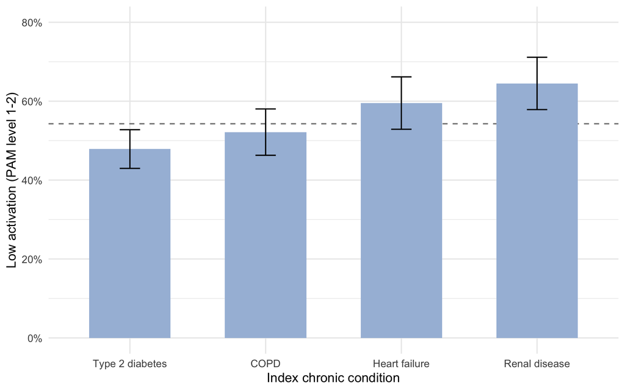

Figure 1. Proportion with low activation (PAM level 1-2) by index disease. Error bars are 95% Wilson confidence intervals; the dashed line is the overall proportion.

The proportion with low activation rises from 48% in the diabetes group to 65% in the renal disease group, with COPD and heart failure in between — a spread of roughly 17 percentage points across the four pooled conditions.

## Univariable models

| **Characteristic** | **N** | **OR** | **95% CI** | **p-value** |
| --- | --- | --- | --- | --- |
| age_yrs | 1,087 | 1.01 | 1.00, 1.02 | 0.090 |
| sex | 1,087 |  |  |  |
| Male |  | — | — |  |
| Female |  | 1.11 | 0.87, 1.42 | 0.4 |
| education_level | 1,087 |  |  |  |
| Lower |  | — | — |  |
| Middle |  | 1.14 | 0.88, 1.48 | 0.3 |
| Higher |  | 0.65 | 0.45, 0.92 | 0.016 |
| disease | 1,087 |  |  |  |
| Type 2 diabetes |  | — | — |  |
| COPD |  | 1.19 | 0.87, 1.61 | 0.3 |
| Heart failure |  | 1.60 | 1.14, 2.25 | 0.006 |
| Renal disease |  | 1.98 | 1.40, 2.82 | <0.001 |
| charlson_index | 1,087 | 1.14 | 1.07, 1.22 | <0.001 |
| ipq_total | 1,087 | 1.05 | 1.03, 1.06 | <0.001 |
| social_support_total | 1,087 | 0.98 | 0.97, 0.99 | <0.001 |

Abbreviations: CI = Confidence Interval, OR = Odds Ratio

## Why adjustment is needed

The crude disease contrasts are the clearest case for adjustment. `charlson_index` confounds them: the renal and heart-failure groups carry more comorbidity than the diabetes group, and comorbidity is itself crudely associated with low activation, so part of the doubled odds in renal patients is simply that they are sicker overall. `ipq_total` confounds them in the same direction: patients with the more visibly threatening conditions hold more threatening illness beliefs, and illness beliefs are the strongest single correlate of activation, so the disease contrasts partly measure differences in illness construal. `education_level` is a third confounder, of the illness perception and social support associations: better-educated patients report both less threatening illness beliefs and higher activation, so the crude IPQ association is partly educational. Because the four disease groups were pooled by design, `disease` has to be in the model for anything else to be read as a within-disease comparison.

## Multivariable model

| **Characteristic** | **OR** | **95% CI** | **p-value** |
| --- | --- | --- | --- |
| age_yrs | 1.00 | 0.99, 1.02 | 0.5 |
| sex |  |  |  |
| Male | — | — |  |
| Female | 1.07 | 0.82, 1.39 | 0.6 |
| education_level |  |  |  |
| Lower | — | — |  |
| Middle | 1.22 | 0.92, 1.61 | 0.2 |
| Higher | 0.79 | 0.54, 1.16 | 0.2 |
| disease |  |  |  |
| Type 2 diabetes | — | — |  |
| COPD | 0.77 | 0.54, 1.07 | 0.12 |
| Heart failure | 1.01 | 0.68, 1.50 | >0.9 |
| Renal disease | 1.37 | 0.92, 2.05 | 0.12 |
| charlson_index | 1.07 | 0.98, 1.16 | 0.13 |
| ipq_total | 1.04 | 1.03, 1.06 | <0.001 |
| social_support_total | 0.98 | 0.98, 0.99 | <0.001 |

Abbreviations: CI = Confidence Interval, OR = Odds Ratio

Model fit

| Statistic | Value |
| --- | --- |
| AIC | 1408.800 |
| Null deviance | 1498.900 |
| Residual deviance | 1386.800 |
| Tjur's R2 | 0.098 |
| N | 1087.000 |
| Events (low activation) | 590.000 |
| Non-events | 497.000 |
| Model parameters (incl. intercept) | 11.000 |
| Events per parameter | 49.700 |

The model has 10 estimated coefficients besides the intercept and the smaller outcome class contains 497 observations, giving about 49.7 events per parameter — far above the conventional minimum of 10, so overfitting and sparse- data bias are not concerns here.

Conditional on all other predictors, only two associations survive. Each extra IPQ point multiplies the odds of low activation by 1.043 (95% CI 1.032 to 1.055, p < 0.001), and each extra point of perceived social support multiplies them by 0.984 (95% CI 0.976 to 0.992, p < 0.001). Comorbidity burden is no longer associated (OR 1.07 per point, 95% CI 0.98 to 1.16, p = 0.13), nor is higher education (OR 0.79, 95% CI 0.54 to 1.16, p = 0.24), nor any disease contrast (renal disease OR 1.37, 95% CI 0.92 to 2.05, p = 0.12), nor age or sex. Discrimination is weak: Tjur’s R² is 0.098, meaning the average predicted probability differs between the two outcome groups by only about 10 percentage points.

## Unadjusted versus adjusted

**Table 2. Unadjusted and adjusted odds ratios.**

| **Characteristic** | **Unadjusted** **N** | **Unadjusted** **OR** | **Unadjusted** **95% CI** | **Unadjusted** **p-value** | **Adjusted** **OR** | **Adjusted** **95% CI** | **Adjusted** **p-value** |
| --- | --- | --- | --- | --- | --- | --- | --- |
| age_yrs | 1,087 | 1.01 | 1.00, 1.02 | 0.090 | 1.00 | 0.99, 1.02 | 0.5 |
| sex | 1,087 |  |  |  |  |  |  |
| Male |  | — | — |  | — | — |  |
| Female |  | 1.11 | 0.87, 1.42 | 0.4 | 1.07 | 0.82, 1.39 | 0.6 |
| education_level | 1,087 |  |  |  |  |  |  |
| Lower |  | — | — |  | — | — |  |
| Middle |  | 1.14 | 0.88, 1.48 | 0.3 | 1.22 | 0.92, 1.61 | 0.2 |
| Higher |  | 0.65 | 0.45, 0.92 | 0.016 | 0.79 | 0.54, 1.16 | 0.2 |
| disease | 1,087 |  |  |  |  |  |  |
| Type 2 diabetes |  | — | — |  | — | — |  |
| COPD |  | 1.19 | 0.87, 1.61 | 0.3 | 0.77 | 0.54, 1.07 | 0.12 |
| Heart failure |  | 1.60 | 1.14, 2.25 | 0.006 | 1.01 | 0.68, 1.50 | >0.9 |
| Renal disease |  | 1.98 | 1.40, 2.82 | <0.001 | 1.37 | 0.92, 2.05 | 0.12 |
| charlson_index | 1,087 | 1.14 | 1.07, 1.22 | <0.001 | 1.07 | 0.98, 1.16 | 0.13 |
| ipq_total | 1,087 | 1.05 | 1.03, 1.06 | <0.001 | 1.04 | 1.03, 1.06 | <0.001 |
| social_support_total | 1,087 | 0.98 | 0.97, 0.99 | <0.001 | 0.98 | 0.98, 0.99 | <0.001 |

Abbreviations: CI = Confidence Interval, OR = Odds Ratio

## Diagnostics

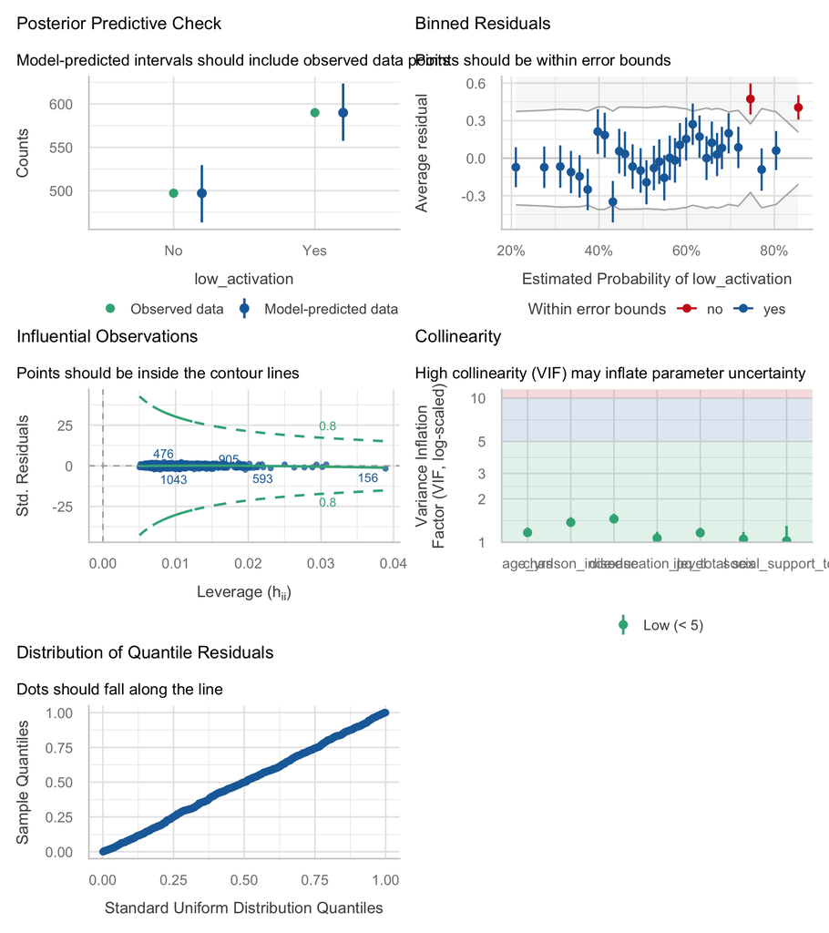

| Term | VIF | VIF_CI_low | VIF_CI_high | SE_factor | Tolerance | Tolerance_CI_low | Tolerance_CI_high |
| --- | --- | --- | --- | --- | --- | --- | --- |
| age_yrs | 1.166857 | 1.104361 | 1.266778 | 1.080212 | 0.8570031 | 0.7894042 | 0.9055010 |
| sex | 1.051098 | 1.014402 | 1.181298 | 1.025231 | 0.9513861 | 0.8465268 | 0.9858027 |
| education_level | 1.068845 | 1.026092 | 1.181647 | 1.033849 | 0.9355897 | 0.8462763 | 0.9745713 |
| disease | 1.451750 | 1.352745 | 1.578542 | 1.204886 | 0.6888238 | 0.6334959 | 0.7392374 |
| charlson_index | 1.373477 | 1.283790 | 1.491506 | 1.171954 | 0.7280794 | 0.6704631 | 0.7789434 |
| ipq_total | 1.162520 | 1.100698 | 1.262295 | 1.078202 | 0.8602005 | 0.7922079 | 0.9085142 |
| social_support_total | 1.024722 | 1.002045 | 1.298849 | 1.012285 | 0.9758745 | 0.7699124 | 0.9979591 |

```
## # Overdispersion test (using simulated residuals)
##
##  dispersion ratio = 1.002
##           p-value = 0.936
```

For a logistic model the relevant panels are binned residuals, collinearity and influential observations; homogeneity of variance and normality of residuals do not apply and are not produced. The binned residual plot has most points inside the error bounds with no systematic curvature, so the linear-in-the-logit assumption for `age_yrs`, `charlson_index`, `ipq_total` and `social_support_total` is acceptable. Collinearity is low: the largest VIF is `disease` at 1.45, then `charlson_index` at 1.37. No observation exceeds the Cook’s distance threshold, so no single participant drives the results. `check_overdispersion()` gives a dispersion ratio of 1.00 (p = 0.93), as expected for a binary outcome. Events per parameter is about 49.7, comfortably adequate. There is no separation: every predictor has a finite coefficient with a finite confidence interval.

# Discussion

Among Dutch adults with one of four chronic conditions, only two characteristics are independently associated with low patient activation: how threatening the patient perceives their illness to be, and how much social support they feel they have. Neither the diagnosis, nor comorbidity burden, nor education, nor age or sex adds anything once those two are known. Practically, this means a clinic cannot identify low-activation patients from routinely recorded demographics and diagnoses — it has to ask them about their beliefs and their support. Even then discrimination is weak (Tjur’s R² = 0.098), so this is a description of associations rather than a usable screening rule.

**Limitations.** The design is cross-sectional, so nothing here shows that changing illness beliefs would change activation; a patient who feels unable to manage may simply come to see their illness as more threatening. IPQ, MSPSS and PAM are all self-reported at the same sitting, so common-method bias inflates the two surviving associations. Dichotomising the PAM at the level 2/3 boundary discards the continuous information in `pam_score` and costs statistical power; the cut point is conventional, not empirical. The file has no disease-specific severity markers — no eGFR or dialysis status, no NYHA class, no GOLD stage — so severity is proxied only by the generic Charlson index, and the attenuation of the renal-disease and heart-failure contrasts should be read with that in mind. Complete-case analysis dropped 67 participants (5.8%). All estimates are associations, not effects.

**Future work.** A prospective study measuring illness perceptions before and after a self-management intervention would test whether the association with activation is modifiable.

# Feasibility notes

*Not part of a student report.*

- **Statistically the safest logistic outcome in this dataset.** 590 events and 497 non-events out of 1087 complete cases — almost a 50/50 split, no sparse cells, no separation, 49.7 events per parameter, max VIF 1.45, dispersion ratio 1.00, no influential points. Nothing breaks.
- **But it is a dichotomised copy of `pam_score`.** `low_activation` is derived from `pam_level`, which is a deterministic banding of `pam_score`. A student who analyses both outcomes is answering the same research question twice, once with the information thrown away. The logistic model finds *fewer* significant predictors than the linear one on the same predictor set — education and the Charlson index survive in the `pam_score` model and are lost here — which is exactly the power cost of dichotomising. If a student must do a logistic analysis, this is a workable outcome; if they have a free choice, `pam_score` is strictly better.
- **Circularity trap is severe.** Putting `pam_score` or `pam_level` on the right-hand side gives complete separation and an infinite coefficient. The brief must forbid this explicitly, because both variables sit in the file right next to the outcome and are the obvious things to grab.
- **Complete-case N = 1087** of 1154 (67 dropped, 5.8%).
- **Weak discrimination.** Tjur’s R² = 0.098. Only two of seven predictors are significant after adjustment, and the whole set of demographic and clinical variables contributes essentially nothing. Students expecting a strong predictive model should be warned.
- **Good confounding story**, though: three crude associations (renal disease, heart failure, Charlson index) are wiped out by adjustment, which makes the unadjusted-versus-adjusted comparison genuinely instructive.